# DATA 624 Homework 6 Chapter 8

## Question 8.1

**Figure 8.31 shows the ACFs for 36 random numbers, 360 random numbers and 1,000 random numbers.**

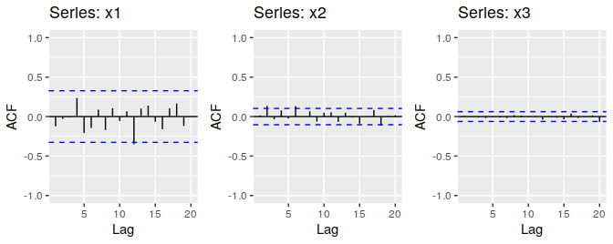

Question 8.1

**Explain the differences among these figures. Do they all indicate that the data are white noise?** These all look like white noise processes becasue all of the auto correlations fall within the 95% confidence interval. I think the differences in the graphs can accounted for simply in the different number of observations in each of the series.

**Why are the critical values at different distances from the mean of zero? Why are the autocorrelations different in each figure when they each refer to white noise?**

According to the law of large numbers As the number of observations increase, the number of large outliers from the mean decreases. We are more certain that a large observation is really an outlier with more data.

## Question 8.2

**A classic example of a non-stationary series is the daily closing IBM stock price series (data set ibmclose). Use R to plot the daily closing prices for IBM stock and the ACF and PACF. Explain how each plot shows that the series is non-stationary and should be differenced.**

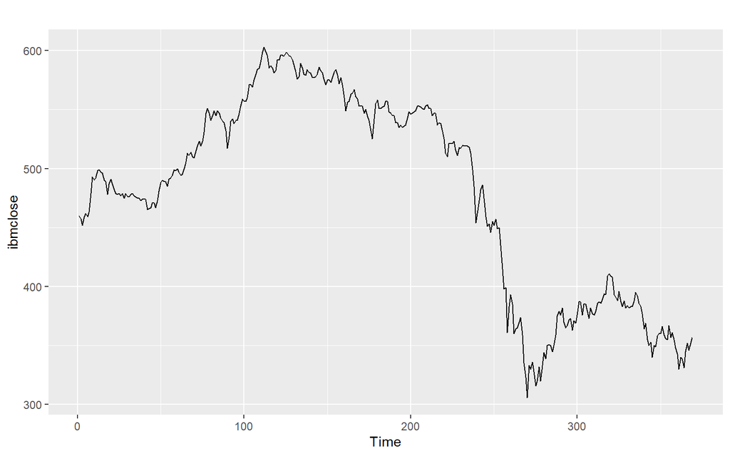

```r
autoplot(ibmclose)
```

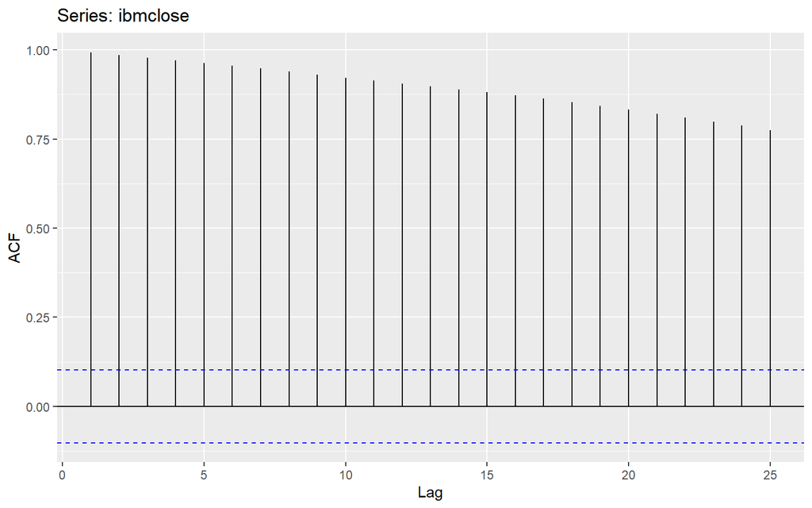

```r
ggAcf(ibmclose)
```

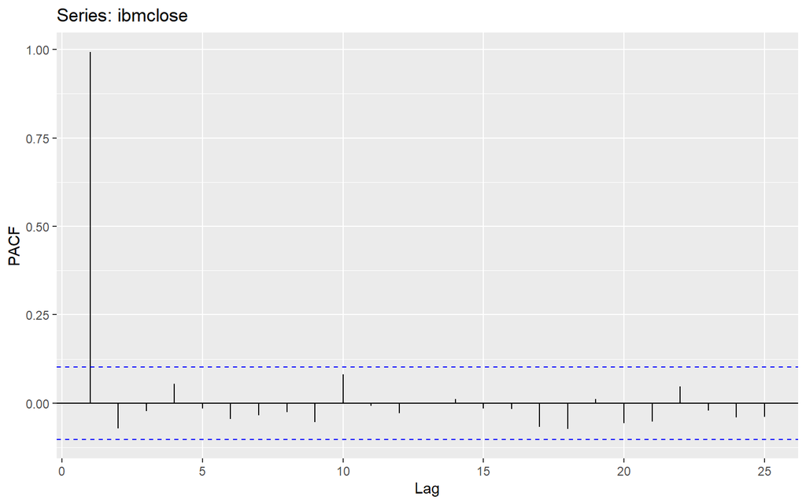

```r
ggPacf(ibmclose)
```

As you can see from the autolplot the ibmclose time series is not stationary in the mean and it does seems to exhibit some seasonal patterns possibly. Because the time series is not stationary it should be differenced. The ACF plots also show a high correlation for the different lags and on the PACF plot the first lag is very high meaning the price of a stock today is heavily dependent on what the price of the stock was yesterday, which makes a lot of sense.

## Question 8.3

**For the following series, find an appropriate Box-Cox transformation and order of differencing in order to obtain stationary data.**

### usnetelec

The trend looks nearly linear

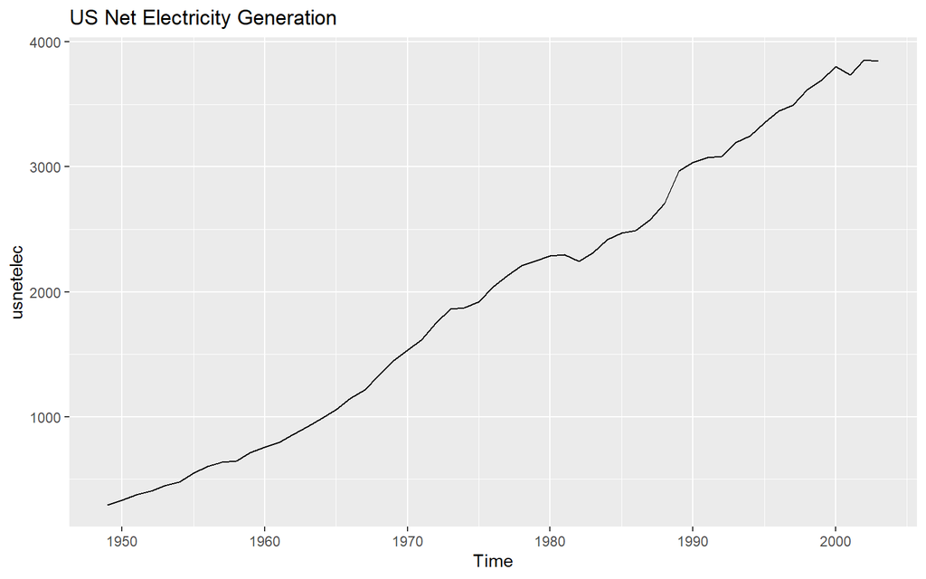

```r
autoplot(usnetelec, main = "US Net Electricity Generation")
```

The ndiffs function says that the series only has to be diffenced once. Since the KPSS test returns a pvalue that is greater than .05 we can conclude that the time series is stationary

```r
library(tseries)
ndiffs(usnetelec)
```

```
## [1] 1
```

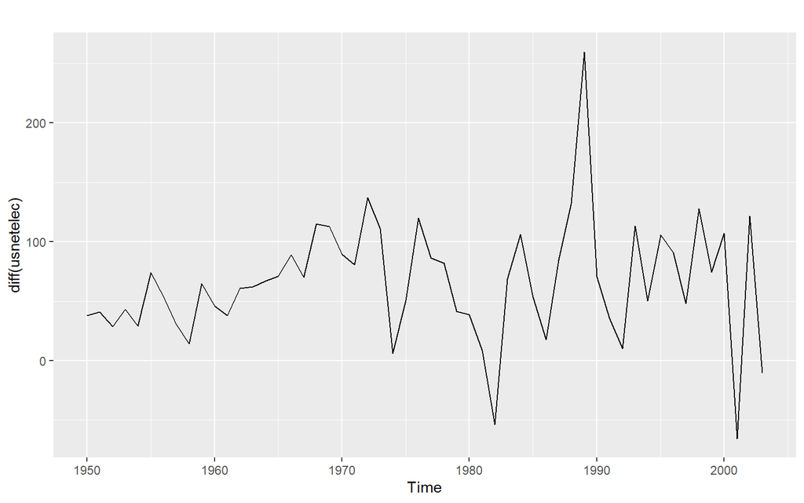

```r
autoplot(diff(usnetelec))
```

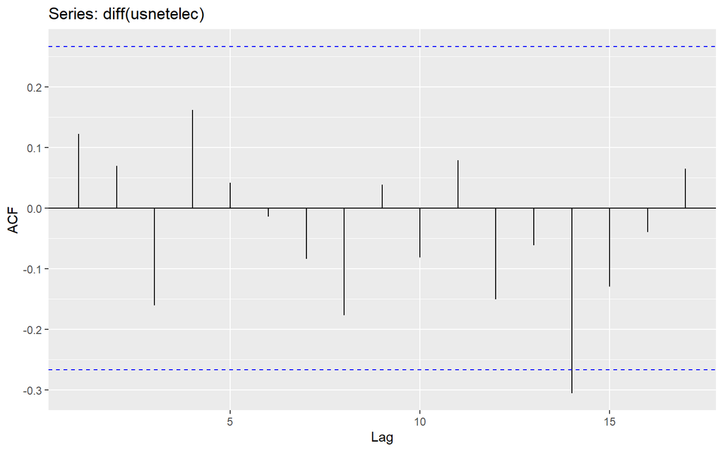

```r
ggAcf(diff(usnetelec))
```

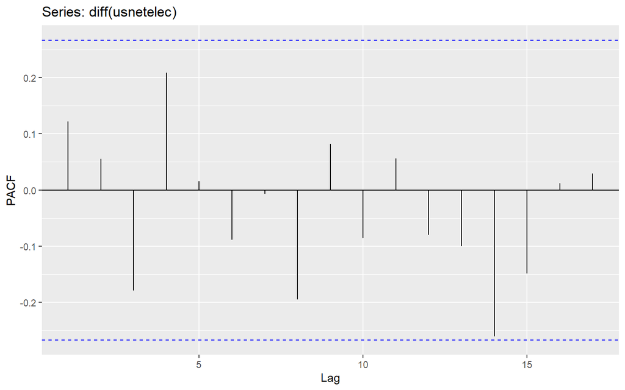

```r
ggPacf(diff(usnetelec))
```

```r
kpss.test(diff(usnetelec))
```

```
##
##  KPSS Test for Level Stationarity
##
## data:  diff(usnetelec)
## KPSS Level = 0.15848, Truncation lag parameter = 3, p-value = 0.1
```

### USGDP

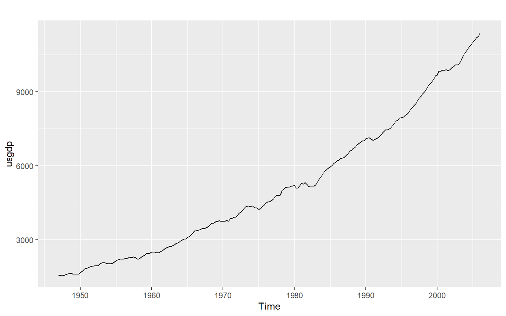

```r
autoplot(usgdp)
```

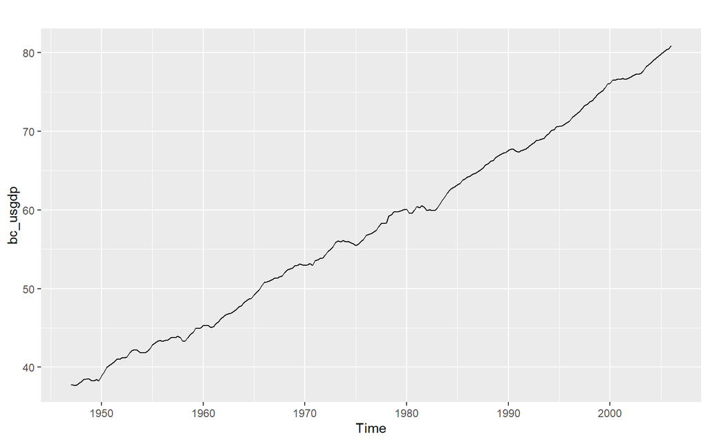

```r
usgdp_lambda <- BoxCox.lambda(usgdp)
bc_usgdp <- BoxCox(usgdp, lambda = usgdp_lambda)
autoplot(bc_usgdp)
```

```r
ndiffs(bc_usgdp)
```

```
## [1] 1
```

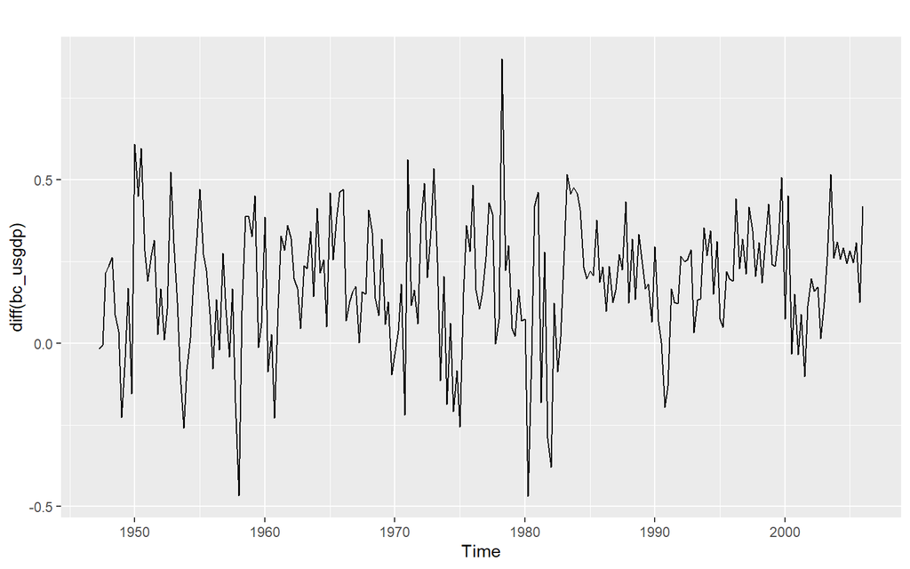

```r
autoplot(diff(bc_usgdp))
```

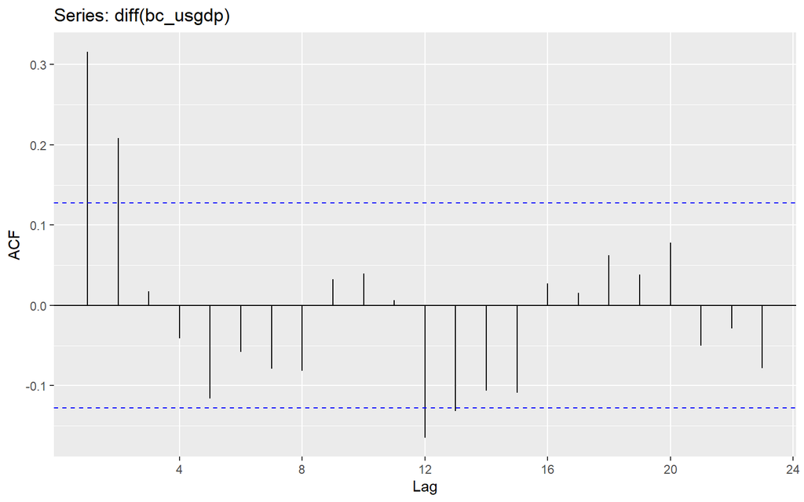

```r
ggAcf(diff(bc_usgdp))
```

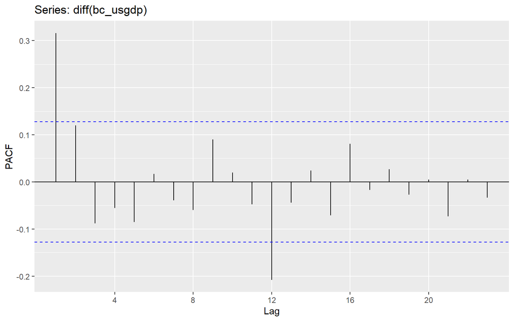

```r
ggPacf(diff(bc_usgdp))
```

```r
kpss.test(diff(bc_usgdp))
```

```
##
##  KPSS Test for Level Stationarity
##
## data:  diff(bc_usgdp)
## KPSS Level = 0.20131, Truncation lag parameter = 4, p-value = 0.1
```

### mcopper

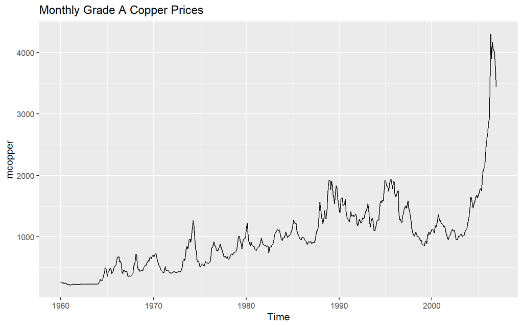

```r
autoplot(mcopper, main = "Monthly Grade A Copper Prices")
```

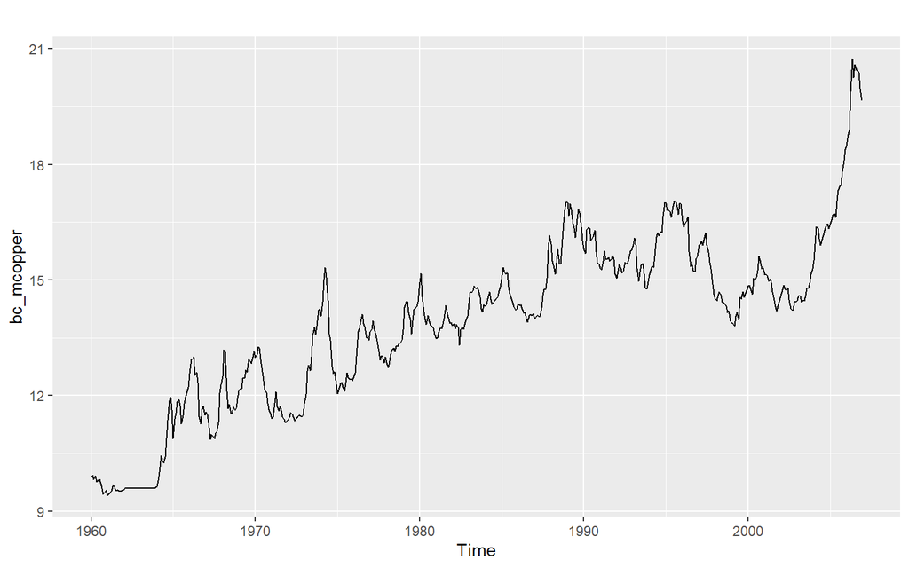

```r
mcopper_lambda <- BoxCox.lambda(mcopper)
bc_mcopper <- BoxCox(mcopper, lambda = mcopper_lambda)
autoplot(bc_mcopper)
```

```r
ndiffs(bc_mcopper)
```

```
## [1] 1
```

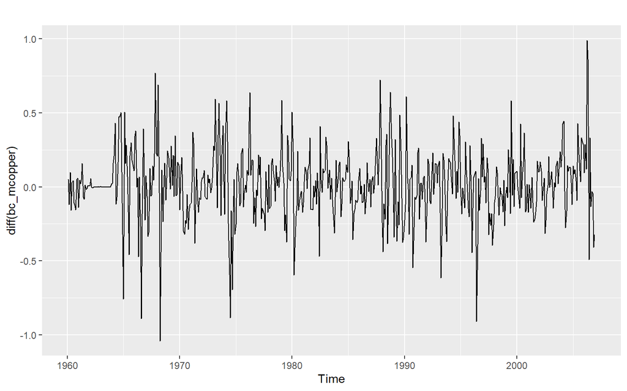

```r
autoplot(diff(bc_mcopper))
```

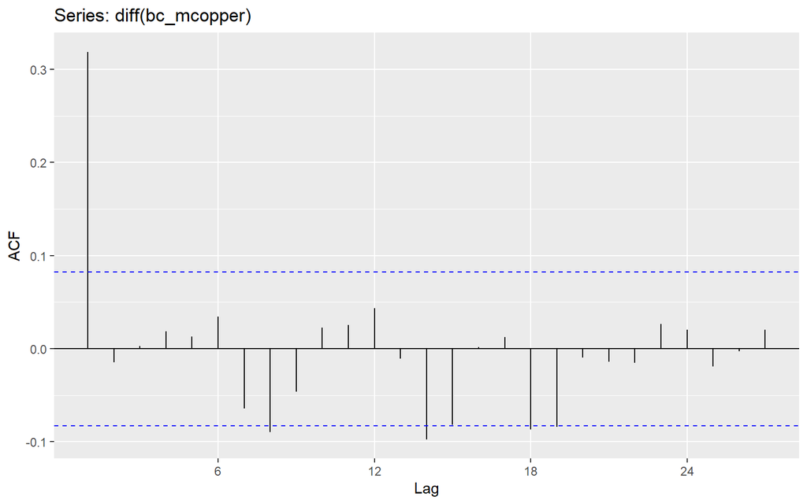

```r
ggAcf(diff(bc_mcopper))
```

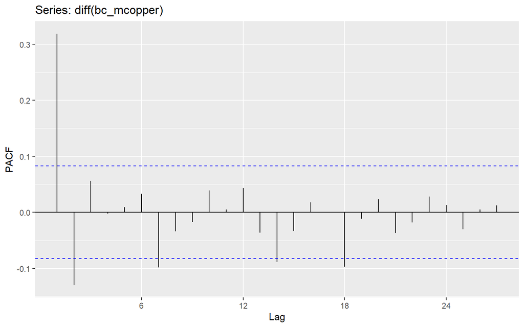

```r
ggPacf(diff(bc_mcopper))
```

```r
kpss.test(diff(bc_mcopper))
```

```
##
##  KPSS Test for Level Stationarity
##
## data:  diff(bc_mcopper)
## KPSS Level = 0.057275, Truncation lag parameter = 6, p-value = 0.1
```

### enplanements

Seems to be seasonal patterns and the data is not stationary

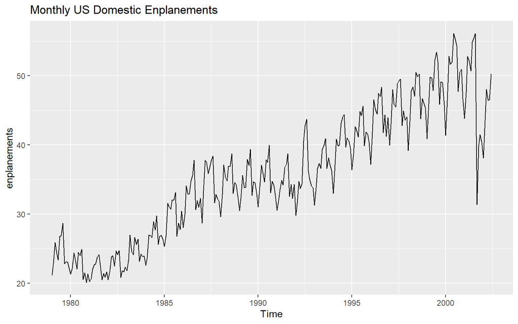

```r
autoplot(enplanements, main = "Monthly US Domestic Enplanements")
```

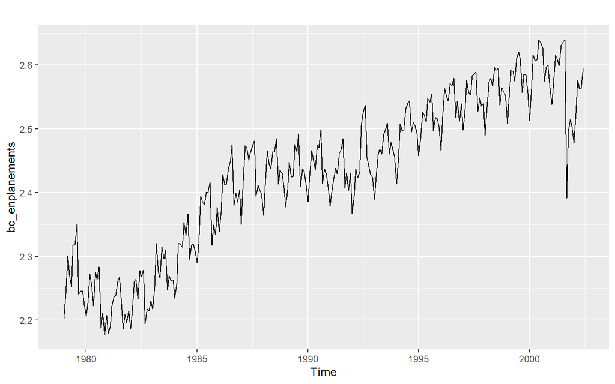

```r
## perform log transfrom and graph the data
enplanements_lambda <- BoxCox.lambda(enplanements)
bc_enplanements <- BoxCox(enplanements, lambda = enplanements_lambda)
autoplot(bc_enplanements)
```

```r
#determine the number of differencing required
ndiffs(bc_enplanements)
```

```
## [1] 1
```

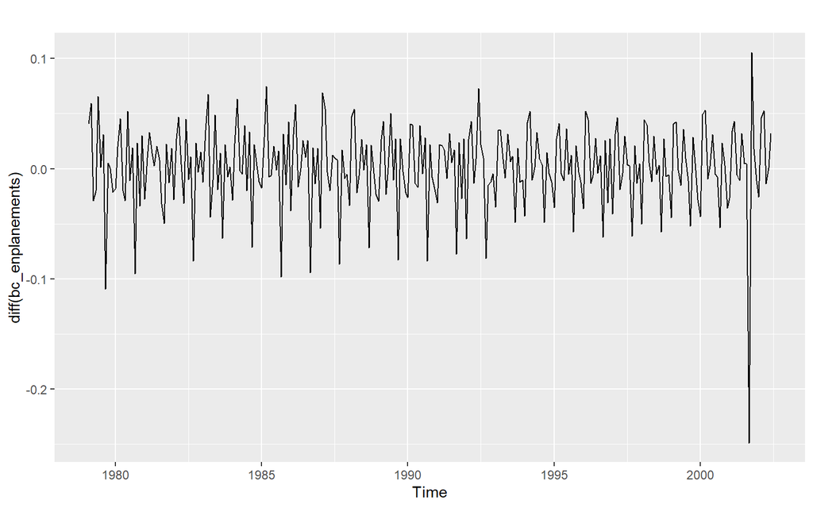

```r
autoplot(diff(bc_enplanements))
```

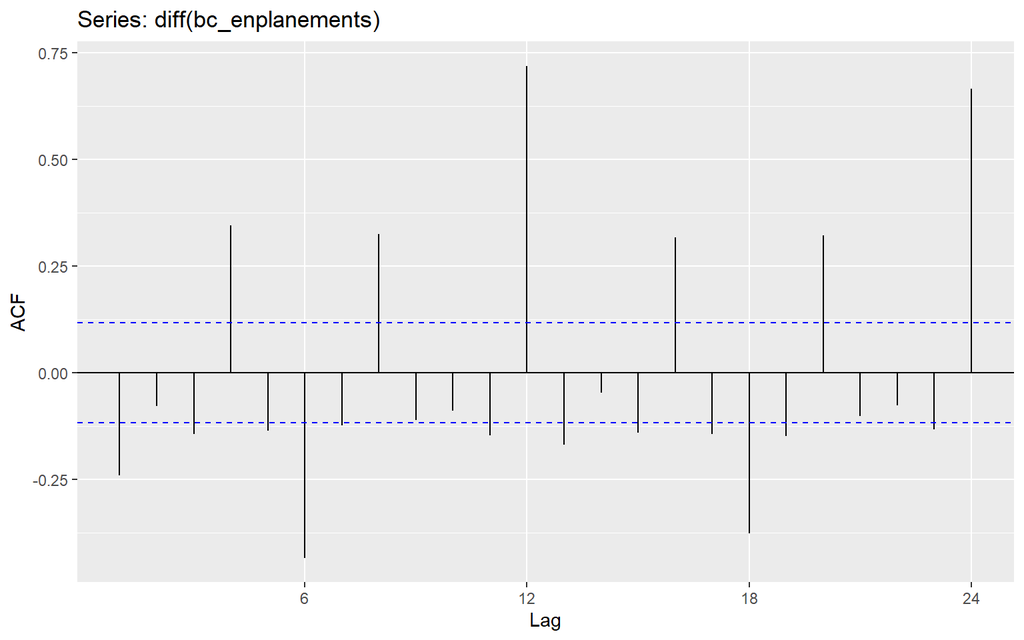

```r
ggAcf(diff(bc_enplanements))
```

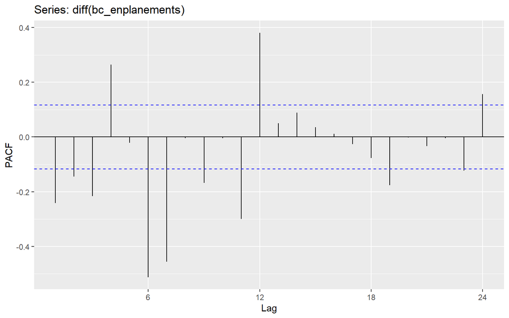

```r
ggPacf(diff(bc_enplanements))
```

```r
kpss.test(diff(bc_enplanements))
```

```
##
##  KPSS Test for Level Stationarity
##
## data:  diff(bc_enplanements)
## KPSS Level = 0.015112, Truncation lag parameter = 5, p-value = 0.1
```

### visitors

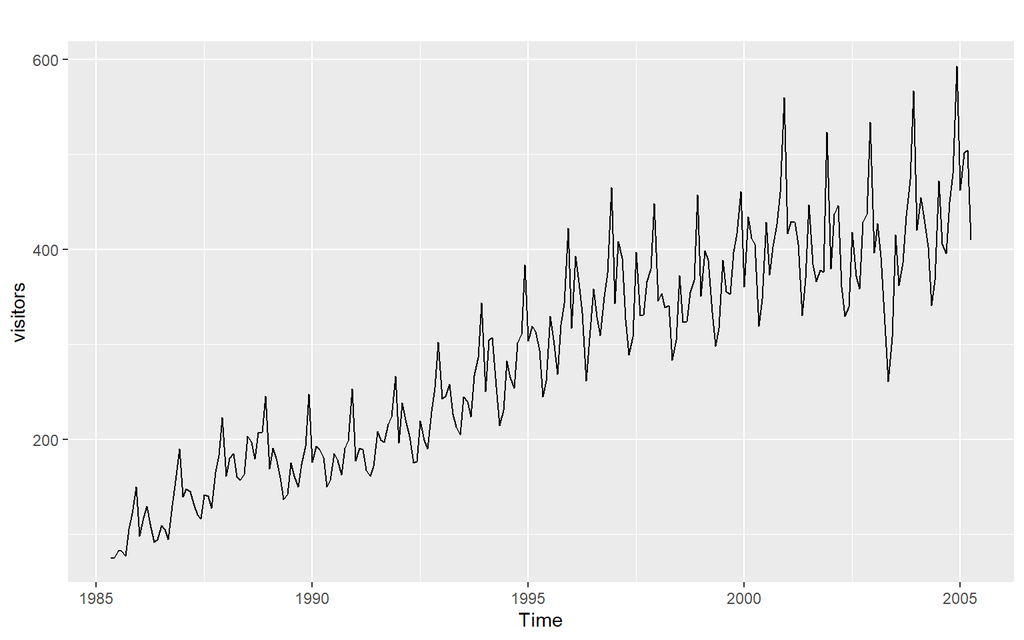

```r
autoplot(visitors)
```

This series has an increasing trend and an increasing variance and a seasonal pattern

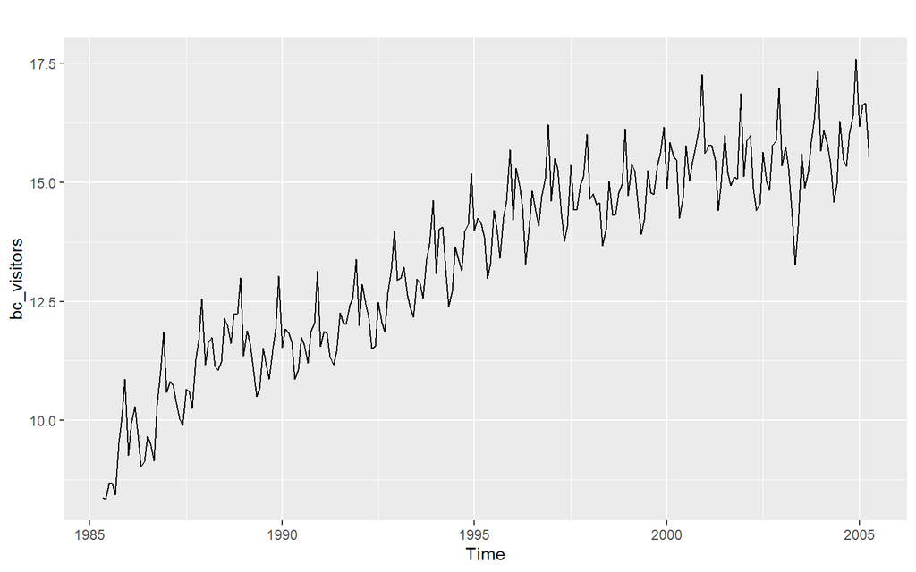

```r
visitors_lambda <- BoxCox.lambda(visitors)
bc_visitors <- BoxCox(visitors, lambda = visitors_lambda)
autoplot(bc_visitors)
```

```r
#determine the number of differencing required
ndiffs(bc_visitors)
```

```
## [1] 1
```

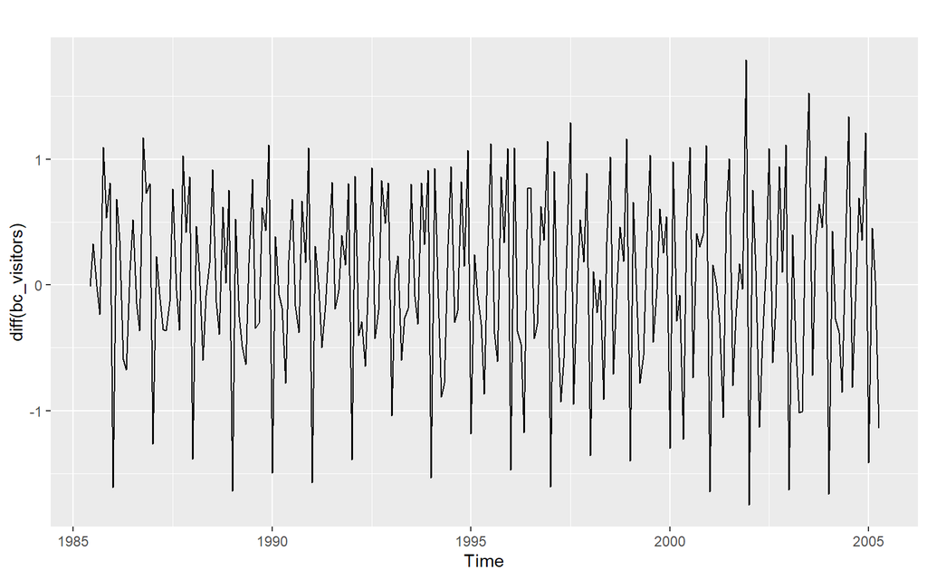

```r
autoplot(diff(bc_visitors))
```

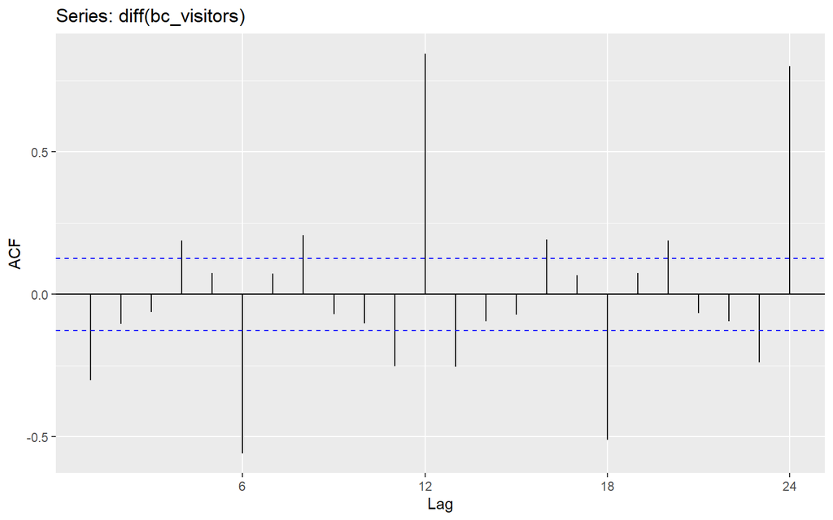

```r
ggAcf(diff(bc_visitors))
```

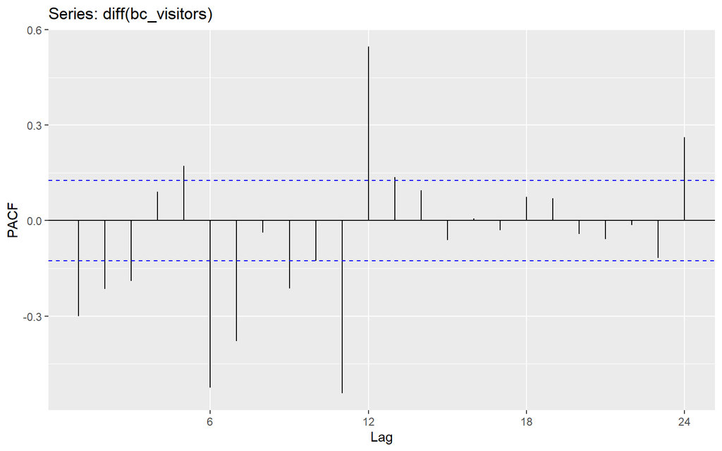

```r
ggPacf(diff(bc_visitors))
```

```r
kpss.test(diff(bc_visitors))
```

```
##
##  KPSS Test for Level Stationarity
##
## data:  diff(bc_visitors)
## KPSS Level = 0.051907, Truncation lag parameter = 4, p-value = 0.1
```

## Question 8.5

**For your retail data (from Exercise 3 in Section 2.10), find the appropriate order of differencing (after transformation if necessary) to obtain stationary data.**

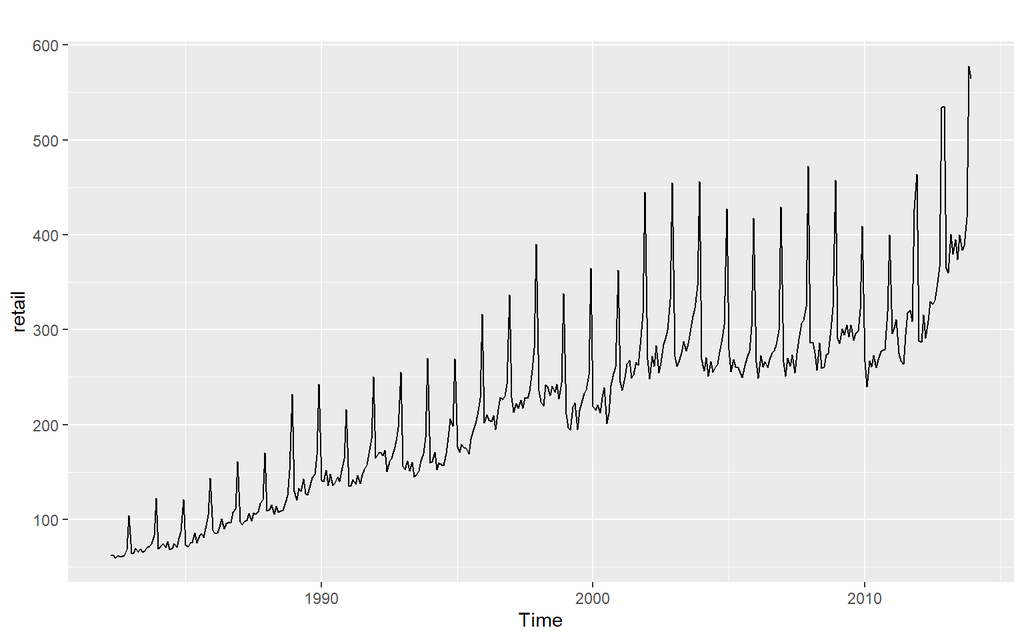

```r
library(readxl)
retaildata <- read_excel("retail.xlsx", skip = 1)
retail <- ts(retaildata[, "A3349873A"], frequency = 12, start = c(1982, 4))
retail_lambda <- BoxCox.lambda(retail)

autoplot(retail)
```

```r
bc_retail <- BoxCox(retail, lambda = retail_lambda)

ndiffs(bc_retail)
```

```
## [1] 1
```

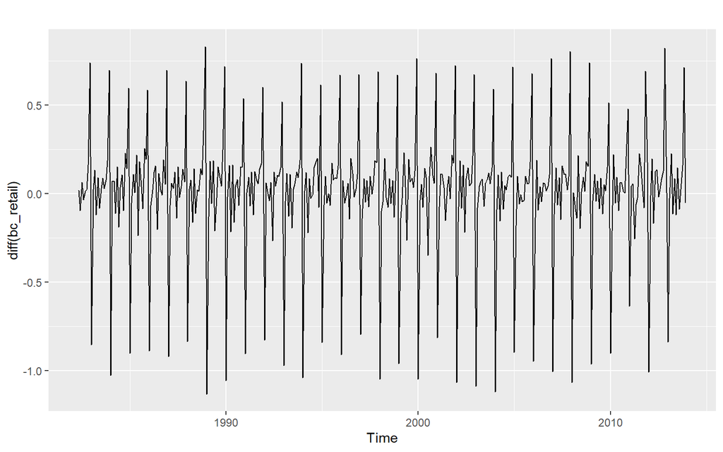

```r
autoplot(diff(bc_retail))
```

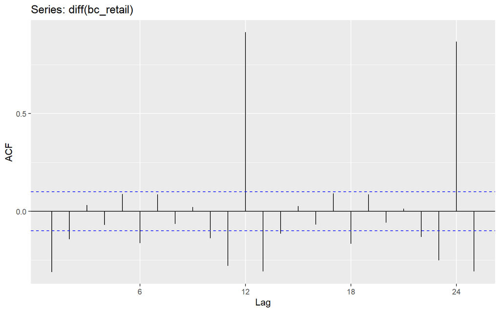

```r
ggAcf(diff(bc_retail))
```

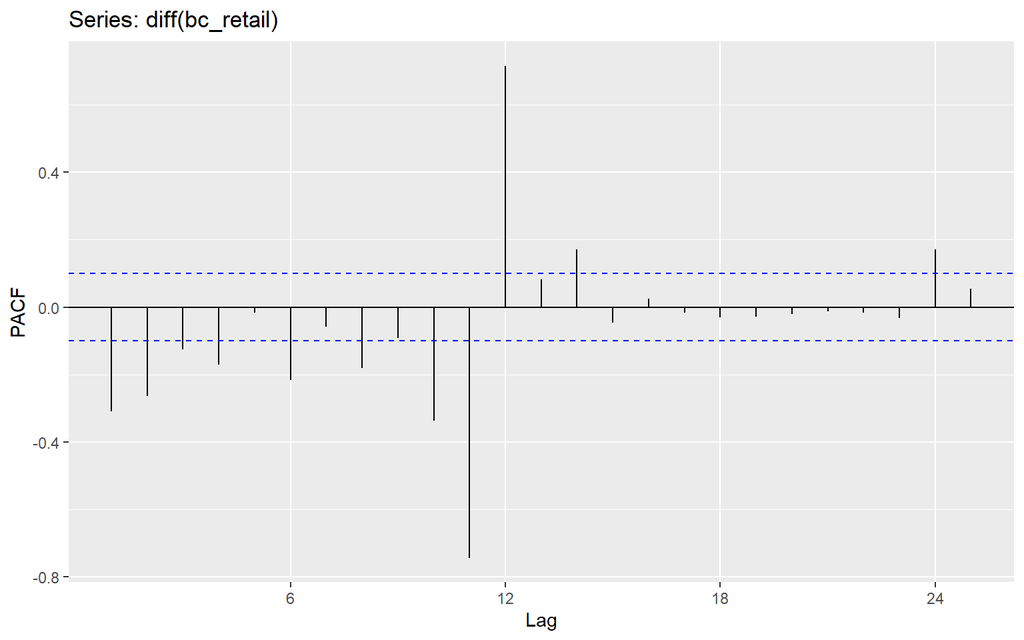

```r
ggPacf(diff(bc_retail))
```

```r
kpss.test(diff(bc_retail))
```

```
##
##  KPSS Test for Level Stationarity
##
## data:  diff(bc_retail)
## KPSS Level = 0.019827, Truncation lag parameter = 5, p-value = 0.1
```